# Module 5 Project Report

stop_drop_and_code

2022-10-10

# Introduction

It has been previously established that body temperature and thermoregulation play integral roles in maintaining homeostasis of the body during forms of physical activity. Lim, Byrne, and Lee (2008) reports that metabolic rate increases drastically during physical activity. Furthermore, this increase in metabolic rate causes an increase in heat production. However, thermoregulation allows us to continue to function and sustains physiological processes. Hyperthermia may also be utilized by the central nervous system to act as a limiting mechanism to prevent damage to the body. This experiment investigates the effect of physical activity on body temperature in humans using temperature sensors.

# Methods

The effect of physical activity on body temperature was assessed by collecting readings of axillary body temperature readings during a resting state and after a period of physical activity. The resting state was defined as having a resting heart rate while sitting on a couch. The active state was defined as being five minute of jumping jacks. Temperature in Celsius was recorded for 100 seconds during the resting state and after the active state in the axillary (armpit) region of each subject. An Arduino unit was used as a prototype along with a DHT11 temperature sensor to measure temperature data.

# Results

[figure not shown]

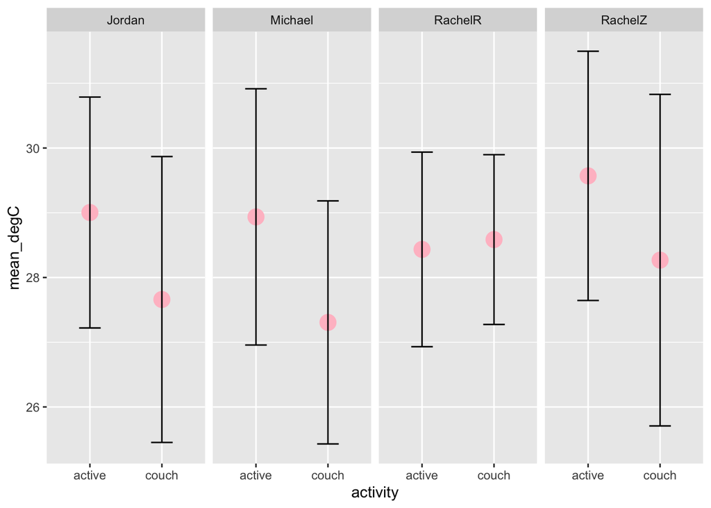

### Results Summary

Our results show that 3/4 (Jordan, Michael, RachelZ) group members had higher mean active body temperatures than mean sedentary body temperatures. RachelR’s mean active body temperature is slightly lower than her mean resting temperature, and the difference between mean active body temperature and mean resting body temperature for RachelR is also slightly lower than Jordan, Michael, and RachelZ’s temperature differences. The SD error bars show that there was a smaller spread for RachelR’s temperatures compared with the rest of the group members.

# Discussion

*Does body temperature vary in human subjects according to activity level?*

# Author Contributions

Rachel R: Arduino setup and code

Rachel Z: Results Summary and Discussion

Jordan: Results, Discussion, Data Collection

Michael: Data collection and production of .csv files, Introduction, Results, Methods

# References

Lim, Chin Leong, Chris Byrne, and Jasom KW Lee. 2008. “Human Thermoregulation and Measurement of Body Temperature in Exercise and Clinical Settings.” *Annals of the Academy of Medicine of Singapore* 37 (4): 347–53.

Wendt, Daniël, Luc JC Van Loon, and Wouter D Marken Lichtenbelt. 2007. “Thermoregulation During Exercise in the Heat.” *Sports Medicine* 37 (8): 669–82.